# STAT 425 - HW4

Josh Janda

30 March, 2020

```r
library(tidyverse)
library(faraway)
```

## Problem 1.

For the salmonella data set fit a linear model with colonies as the response, and log(dose + 1) as predictor. Check for lack of fit.

```r
salmonella_mod = lm(colonies ~ I(log(dose + 1)),
                    data = salmonella)

r2_salmonella = summary(salmonella_mod)$r.sq
summary(salmonella_mod)
```

```
##
## Call:
## lm(formula = colonies ~ I(log(dose + 1)), data = salmonella)
##
## Residuals:
##     Min      1Q  Median      3Q     Max
## -16.376  -6.882  -1.509   5.400  29.119
##
## Coefficients:
##                  Estimate Std. Error t value Pr(>|t|)
## (Intercept)        19.823      5.064   3.915  0.00123 **
## I(log(dose + 1))    2.396      1.128   2.125  0.04955 *
## ---
## Signif. codes:  0 '***' 0.001 '**' 0.01 '*' 0.05 '.' 0.1 ' ' 1
##
## Residual standard error: 10.84 on 16 degrees of freedom
## Multiple R-squared:  0.2201, Adjusted R-squared:  0.1713
## F-statistic: 4.514 on 1 and 16 DF,  p-value: 0.04955
```

Looking at the summary output above, we see that the predictor is significant at $\alpha = .05$. Since it is a simple linear regression model, we get the same p-value with our associated F-Statistic. We get an R-Squared of 0.22, which is okay.

Overall, our model is significant and judging by the $R^2$ value there is somewhat of a fit. Let’s look at the model visually and check the fit.

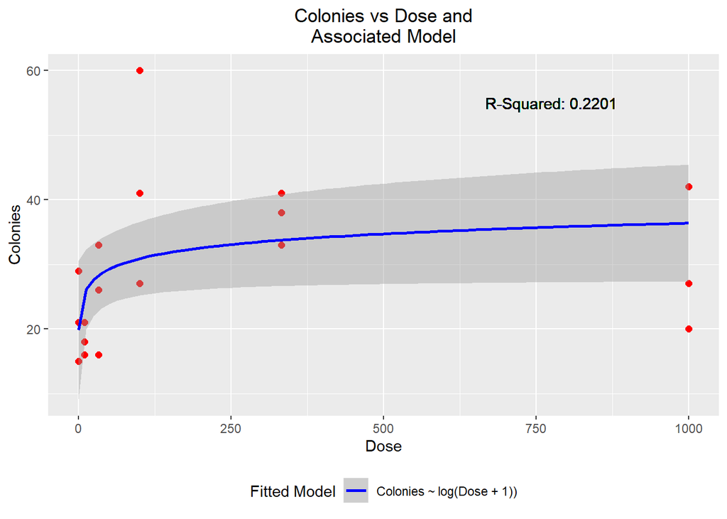

```r
ggplot(data = salmonella, aes(x = dose, y = colonies)) +
  geom_point(color = 'red', size = 2) +
  geom_smooth(formula = y ~ I(log(x + 1)), method = 'lm', aes(color = 'Colonies ~ log(Dose + 1))')) +
  geom_text(x = 775, y = 55, label = paste('R-Squared:',round(r2_salmonella, 4))) +
  labs(x = 'Dose', y = 'Colonies', color = 'Fitted Model',
       title = 'Colonies vs Dose and\nAssociated Model') +
  scale_color_manual(values = c('blue')) +
  theme(legend.position = 'bottom',
        plot.title = element_text(hjust = 0.5))
```

In order to fully check for a lack of fit, we must compare this model to a model using dose as a factor variable.

```r
salmonella_mod2 = lm(colonies ~ factor(I(log(dose + 1))),
                    data = salmonella)

anova(salmonella_mod, salmonella_mod2)
```

```
## Analysis of Variance Table
##
## Model 1: colonies ~ I(log(dose + 1))
## Model 2: colonies ~ factor(I(log(dose + 1)))
##   Res.Df    RSS Df Sum of Sq      F Pr(>F)
## 1     16 1881.1
## 2     12 1091.3  4    789.73 2.1709 0.1342
```

With a p-value > .05, we can further claim that there is not a lack of fit in this model. This model is useful and does not seem to break constant variance assumptions.

## Problem 2.

The gammaray dataset shows the x-ray decay light curve of gamma ray burst. Build a model to predict the flux as a function of time that uses appropriate weights.

For this, I will be using the following procedure to obtain the appropriate weights:

1. Fit model flux ~ time
2. Obtain absolute residuals from this model
3. Fit absolute residuals ~ flux model
4. Obtain fitted values from model
5. Create weights equal to $\frac{1}{fitted^2}$

```r
gammaray_model = lm(flux ~ time,
                    data = gammaray) #1

absolute_resids = abs(gammaray_model$residuals) #2

resid_mod = lm(absolute_resids ~ flux, data = gammaray) #3

fitted = resid_mod$fitted.values #4

weights = 1 / fitted^2

gammaray_model_w = lm(flux ~ time,
                      data = gammaray, weights = weights)

summary(gammaray_model)
```

```
##
## Call:
## lm(formula = flux ~ time, data = gammaray)
##
## Residuals:
##     Min      1Q  Median      3Q     Max
## -34.745 -18.553  -8.154  13.598  85.974
##
## Coefficients:
##               Estimate Std. Error t value Pr(>|t|)
## (Intercept)  3.675e+01  3.691e+00   9.955 2.12e-14 ***
## time        -1.547e-04  6.283e-05  -2.462   0.0167 *
## ---
## Signif. codes:  0 '***' 0.001 '**' 0.01 '*' 0.05 '.' 0.1 ' ' 1
##
## Residual standard error: 28.34 on 61 degrees of freedom
## Multiple R-squared:  0.09037,    Adjusted R-squared:  0.07545
## F-statistic:  6.06 on 1 and 61 DF,  p-value: 0.01667
```

Without weights, we see an $R^2$ value of ~ .09 on the model with a p-value of ~.0167. Therefore, this model is significant at $\alpha=.05$ but with a low $R^2$ value the fit is questionable.

```r
summary(gammaray_model_w)
```

```
##
## Call:
## lm(formula = flux ~ time, data = gammaray, weights = weights)
##
## Weighted Residuals:
##     Min      1Q  Median      3Q     Max
## -1.5272 -0.1834  0.4187  1.1464  2.1850
##
## Coefficients:
##               Estimate Std. Error t value Pr(>|t|)
## (Intercept)  2.011e+01  2.768e+00   7.266 8.08e-10 ***
## time        -8.378e-05  3.147e-05  -2.662  0.00992 **
## ---
## Signif. codes:  0 '***' 0.001 '**' 0.01 '*' 0.05 '.' 0.1 ' ' 1
##
## Residual standard error: 1.132 on 61 degrees of freedom
## Multiple R-squared:  0.1041, Adjusted R-squared:  0.08938
## F-statistic: 7.086 on 1 and 61 DF,  p-value: 0.00992
```

Using the created weights, we now see an $R^2$ value of ~.104 with a p-value of ~.0099. Therefore, this model is significant at $\alpha=.01$ with a slightly higher $R^2$ value than before.

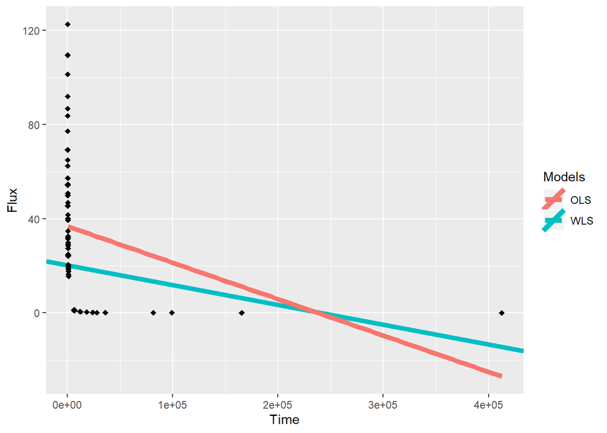

```r
ggplot(data = gammaray, aes(x = time, y = flux)) +
  geom_abline(aes(intercept = gammaray_model_w$coefficients[1],
                  slope = gammaray_model_w$coefficients[2], color = 'WLS'),
              lwd = 2) +
  geom_smooth(formula = y ~ x, method = 'lm', se = FALSE, aes(color = 'OLS'),
              lwd = 2) +
  geom_point(color = 'black', pch = 18, size = 2) +
  labs(x = 'Time', y = 'Flux', color = 'Models')
```

Judging by the plot above, we see that the OLS model is a much worse approximate fit of the data. With WLS, we such a much more generalized fit that better passes through potential influence observations.

Overall, I have created a model using appropriate weights to predict flux given time.

## Problem 3.

For the longley data, fit a model with Employed as the response and the other variables as predictors.

```r
longley_mod = lm(Employed ~ ., data = longley)
```

### A.

Compute and comment on the Condition numbers

```r
model_mtx = model.matrix(longley_mod)[, -1] # get design matrix

model_mtx_scaled = scale(model_mtx) #scale variables to have mean 0 and variance 1

apply(model_mtx_scaled, 2, mean)
```

```
##  GNP.deflator           GNP    Unemployed  Armed.Forces    Population
## -4.774826e-16 -1.118897e-16 -5.724587e-17  5.767956e-17  8.949411e-16
##          Year
##  0.000000e+00
```

using the output above, we can see that all predictors now have a mean of zero (or extremely close to zero).

```r
apply(model_mtx_scaled, 2, var)
```

```
## GNP.deflator          GNP   Unemployed Armed.Forces   Population
##            1            1            1            1            1
##         Year
##            1
```

using the output above, we can see that all predictors now have a variance of one.

We can now use the scaled design matrix to calculate the conditon numbers.

```r
eigen_vals = eigen(t(model_mtx_scaled) %*% model_mtx_scaled)
sqrt(eigen_vals$values[1] / eigen_vals$values)
```

```
## [1]   1.000000   1.979048   4.757028  17.560372  42.470986 110.544153
```

Using the output above, we see that we have condition numbers greater than or equal to 30. This tells me that we have a collinearity problem in this model. To further look into this issue, I will look at the correlation matrix.

### B.

Compute and comment on the correlation between predictors

```r
round(cor(longley[, -7]), dig=2)
```

```
##              GNP.deflator  GNP Unemployed Armed.Forces Population Year
## GNP.deflator         1.00 0.99       0.62         0.46       0.98 0.99
## GNP                  0.99 1.00       0.60         0.45       0.99 1.00
## Unemployed           0.62 0.60       1.00        -0.18       0.69 0.67
## Armed.Forces         0.46 0.45      -0.18         1.00       0.36 0.42
## Population           0.98 0.99       0.69         0.36       1.00 0.99
## Year                 0.99 1.00       0.67         0.42       0.99 1.00
```

Looking at the correlation matrix above we are able to see the correlation between each predictor.

There are some immediate issues that arise when observing this matrix:

- The correlation between GNP Deflator and GNP is .99, meaning these variables are almost an exact linear combination of each other.
- The correlation between GNP Deflator and Population is .98, meaning these variables are almost an exact linear combination of each other.
- The correlation between GNP Deflator and Year is .99, meaning these variables are almost an exact linear combination of each other.
- The correlation between GNP and Population is .99, meaning these variables are almost an exact linear combination of each other.
- The correlation between GNP and Year is 1.00, meaning these variables are almost an exact linear combination of each other.
- The correlation between Population and Year is .99, meaning these variables are almost an exact linear combination of each other.

Overall, looking at the correlation matrix it may be best to remove **Population**, **Year**, and **GNP Deflator** as they all are extremely correlated with GNP. Being that this dataset is time series, this is understandable to see these variables correlated by time.

### C.

Compute and comment on the variance inflation factors.

```r
round(vif(model_mtx_scaled), 2)
```

```
## GNP.deflator          GNP   Unemployed Armed.Forces   Population
##       135.53      1788.51        33.62         3.59       399.15
##         Year
##       758.98
```

```r
sqrt_vif = sqrt(round(vif(model_mtx_scaled), 2))
```

Looking at the Variance Inflation Factors above, we see that:

- The SE for **GNP Deflator** is 11.6417353 larger than it would have been without collinearity.
- The SE for **GNP** is 42.2907791 larger than it would have been without collinearity.
- The SE for **Unemployed** is 5.7982756 larger than it would have been without collinearity.
- The SE for **Armed Forces** is 1.8947295 larger than it would have been without collinearity.
- The SE for **Population** is 19.9787387 larger than it would have been without collinearity.
- The SE for **Year** is 27.5495916 larger than it would have been without collinearity.

Using the variance inflation factors, I can further confirm the large collinearity issues between GNP Deflator, GNP, Population, and Year. This can be remedied by removing possible causal variables such as Population, and GNP Deflator. These issues arise due to the time series nature of this dataset. Possibly adding a lag will remedy this collinearity problem.